# 概要

ターゲット

- 制御工学を一通りかじった程度の人間が分かるような理論要点集がほしい
- 一次遅れ・二次遅れについて上記理論を適用した要点集がほしい
- 理論は周波数領域の話ばかりなので時間領域でどうなるか具体的に知りたい
- 周波数領域での制御設計をプログラムベースに落とし込んだらどうなるかまとめたい

参考書 (非常にいい本だった)

- 現場で役立つ制御工学の基本 (涌井信二 他)

```python
from numpy import *
from matplotlib.pyplot import *
from control.matlab import *
import itertools as it
import pandas as pd

import matplotlib as mpl
zoom=1.3
mpl.rcParams['figure.figsize'] = [6.4 *zoom , 4.8*zoom]
mpl.rcParams['figure.dpi'] = 80*zoom
mpl.rcParams['lines.linewidth'] = 2.0
ion()
```

# 基本的なこと

## 機械と電気の対応

| 並進 | 回転 | 電気 |
| --- | --- | --- |
| 力 $f$ | トルク $\tau$ | 電圧 $v$ |
| 位置 $x$ | 角度 $\theta$ | 電荷 $q$ |
| バネ係数 $f=kx$ | バネ係数 $\tau=k\theta$ | 静電容量 $v=\frac{1}{C}q$ |
| 速度 $v=\frac{dx}{dt}$ | 角速度 $\omega=\frac{d\theta}{dt}$ | 電流 $i=\frac{dq}{dt}$ |
| ダンパ係数 $f=dv$ | ダンパ係数 $f=d\omega$ | 抵抗値 $v=Ri$ |
| 加速度 $a=\frac{dv}{dt}$ | 角加速度 $\alpha=\frac{d\omega}{dt}$ | ??? $ \frac{di}{dt}$ |
| 質量 $m$ | 慣性モーメント $J$ | インダクタンス $L$ |

## 周波数伝達関数

伝達関数$G(s)$に正弦波を入力したときの出力は、定常状態にて振幅が入力の$\alpha$倍、位相が入力から$\beta$[rad]遅れた正弦波になる $\alpha,\beta$は周波数伝達関数$G(j\omega)$を用いて以下で表す事ができる(付録で証明)

$$\alpha=|G(j \omega)| = \sqrt{(Re(G(j\omega))^2 + Im(G(j\omega))^2}$$$$\beta=\angle G(j\omega)=tan^{-1}\left(\frac{Im(G(j\omega))}{Re(G(j\omega))}\right)$$

ボード線図はゲイン$=20log(|G(j \omega)|)$と、位相遅れ$\angle G(j\omega)$をそれぞれ横軸=周波数でプロットしたもの。 実験的には、正弦波の周波数を振りながら入力し、定常出力の振幅と位相遅れをプロットしていけば良い

ゲインの考え方の例は以下

- ゲイン20db = 入力の10倍
- ゲイン-20db = 入力の0.1倍
- ゲイン-3db = -20db+17db = 0.1倍*7.07倍 = 0.7倍
- ゲイン35db = 20db+15db = 10倍*5.62倍 = 56.2倍
- ゲイン2dbと5dbがどれだけ違う？ = (5db-2db) = 3db = 5dbは2dbの1.41倍
- ゲインをgとおくと倍率=$10^\frac{g}{20}=1.122^g$倍
- ゲインg1,g2の倍率比=$10^\frac{g1}{20} / 10^\frac{g2}{20}=1.122^{(g1-g2)}$倍

ゲインと$\alpha$倍の関係は以下の対応表参照。

```
-20.0     0.100000
-19.0     0.112202
-18.0     0.125893
-17.0     0.141254
-16.0     0.158489
-15.0     0.177828
-14.0     0.199526
-13.0     0.223872
-12.0     0.251189
-11.0     0.281838
-10.0     0.316228
-9.0      0.354813
-8.0      0.398107
-7.0      0.446684
-6.0      0.501187
-5.0      0.562341
-4.0      0.630957
-3.0      0.707946
-2.0      0.794328
-1.0      0.891251
 0.0      1.000000
 1.0      1.122018
 2.0      1.258925
 3.0      1.412538
 4.0      1.584893
 5.0      1.778279
 6.0      1.995262
 7.0      2.238721
 8.0      2.511886
 9.0      2.818383
 10.0     3.162278
 11.0     3.548134
 12.0     3.981072
 13.0     4.466836
 14.0     5.011872
 15.0     5.623413
 16.0     6.309573
 17.0     7.079458
 18.0     7.943282
 19.0     8.912509
 20.0    10.000000
dtype: float64
```

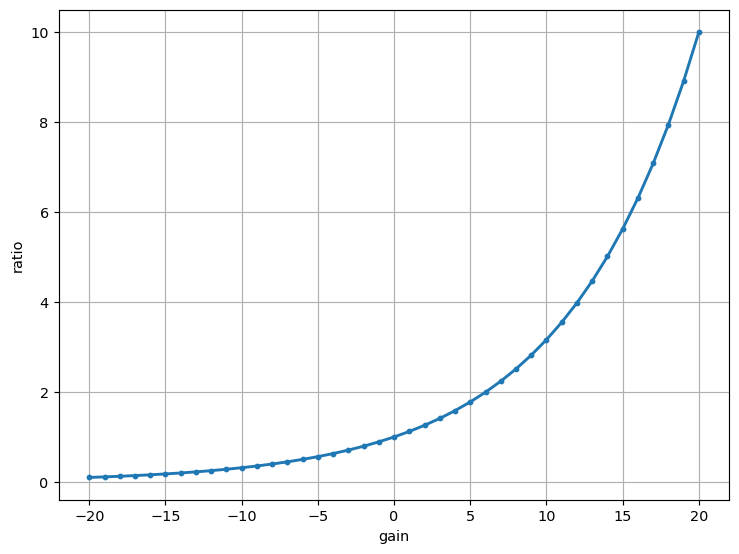

```python
x=np.linspace(-20,20,41)
y=pow(10,x/20)
figure()
plot(x,y,'.-')
grid()
xlabel("gain")
ylabel("ratio")
p = pd.Series(data=y,index=x)
print(p)
```

## 極配置の見方

- 根と実軸のなす角$\theta$が大きいと，減衰係数$\zeta$は小さい($cos\theta = \zeta$)
- 原点に近い極は周波数が低い
- 右半平面の極は発散する

## 安定性判別

```
─┬─C(s)─G(s)─┬─>
 └───H(s)────┘
```

$$CL(s)=\frac{F(s)}{1+OL(s)} = \frac{C(s)G(s)}{1+C(s)G(s)H(s)}$$

- CL(s) : closed-loop 伝達関数
- F(s) : Forward 方向伝達関数
- OL(s) : open-loop 伝達関数 (一巡伝達関数)
- C(s) : コントローラ
- G(s) : 制御対象システム
- H(s) : 検出器

安定条件

- closed-loop伝達関数のすべての極がs平面の左半平面にあること
  - フィードバック含めた系全体の極配置=応答を考えている
  - ラウス・フルビッツの方法で解析的に確認できる
- 一巡伝達関数の位相余裕・ゲイン余裕が確保されていること
  - 入力が一周して戻ってきたときに正帰還になっていないかを考えている
  - ボード線図・ナイキスト線図で実験的に確認できる
  - だいたいゲイン余裕10-20db，位相余裕40-60degくらいが良いらしい

外部安定

- LTIの安定と言われるのは大体BIBO(Boundary Input Boundary Output)安定
  - ざっくりインパルス入力の応答が収束すること
  - インパルス入力の応答の積分値が収束=有界=Boundaryって言葉が出てくる
- 系全体の入出力関係がBIBO安定 = 外部安定
- 系のサブシステム全ての入出力関係が安定 = 内部安定
  - 極零相殺が起きてるようなシステムは外部安定に見えても，内部安定でない場合があるから注意

# 一次遅れ

一般系 $$G(s) = \frac{K}{Ts+1}$$ $$T\frac{dy}{dt}+y=Kx$$

インパルス応答解 $$\mathcal{L}^{-1}\left[\frac{K}{Ts+1}\right] = \frac{K}{T}e^{-\frac{t}{T}}$$ ステップ応答解 $$\mathcal{L}^{-1}\left[\frac{K}{Ts+1}\frac{1}{s}\right] = K \left( 1-e^{-\frac{t}{T}} \right)$$

- 折点周波数$f_0 =\frac{1}{2\pi T}$ Hz
- 低域ゲイン$g = 20 log_{10}(K)$ db
- 折点周波数にてゲイン=-3db,位相遅れ45deg
- ゲイン-3dbになる周波数を「バンド幅」という人もいる．一次遅れだと折点周波数に等しい

## 代表的な例

LR回路 (電流が電圧に対して一次遅れ) $$ \begin{eqnarray} L\frac{di}{dt} + Ri &=&v \\ \iff \frac{L}{R}\frac{di}{dt} + i &=&\frac{1}{R}v \end{eqnarray} $$ より， $$T=\frac{L}{R}$$ $$K=\frac{1}{R}$$

RC回路 (電荷∝充電電圧が電圧に対して一次遅れ) $$Ri+\frac{1}{C} \int qdt = v$$ ここで，$i=\frac{dq}{dt}$より， $$ \begin{eqnarray} R\frac{dq}{dt} + \frac{1}{C}q &=&v \\ \iff RC\frac{dq}{dt} + q &=& Cv \end{eqnarray} $$ より， $$T=RC$$ $$K=C$$

## 時間応答

Tが小さいと応答性が良い Kは応答性には影響せず，Kが大きいと出力スケールが大きくなる

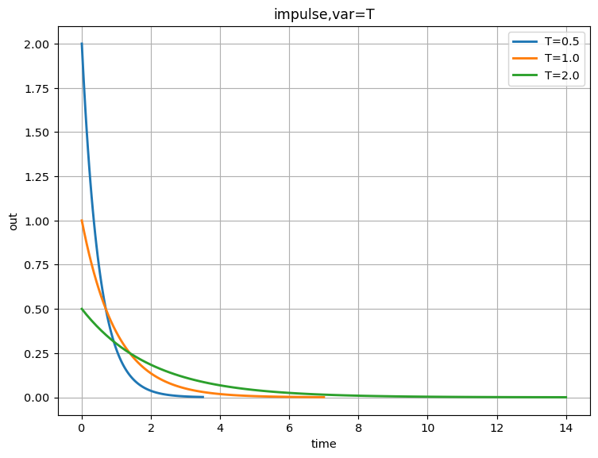

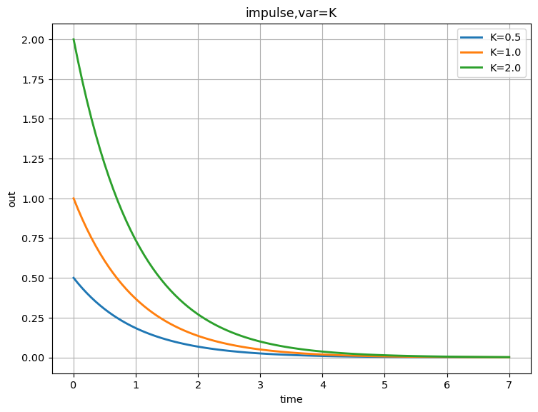

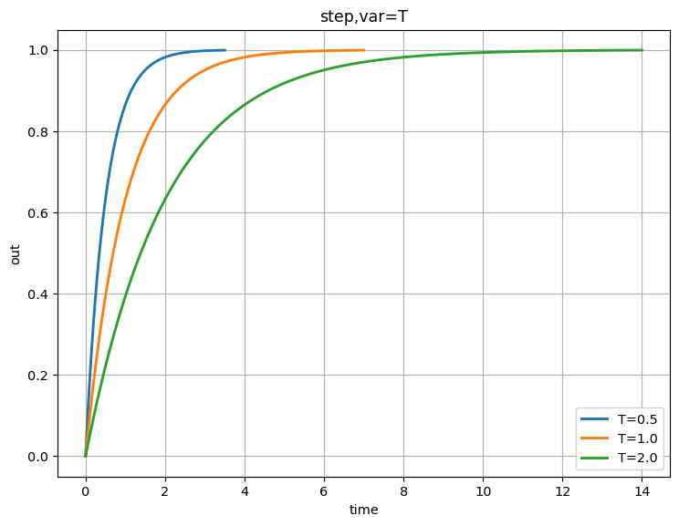

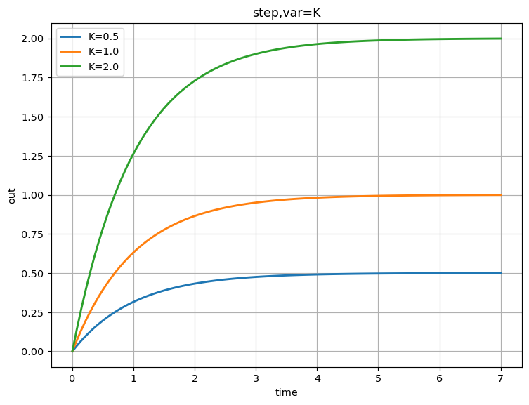

```python
def sys_1st(K,T):
    return tf([K],[T,1])

def sys_2nd(K,wn,zeta):
    return tf([K*wn*wn],[1,2*zeta*wn,wn*wn])

def get_responces(sysparam,sysfunc,resfunc,label_prefix=""):
    systems = [sysfunc(s) for s in sysparam]
    out = [resfunc(sys) for sys in systems]
    data = [(tup[1],tup[0],s,label_prefix) for s,tup in zip(sysparam,out)]
    return data

def draw_alldata(data,linspec='-'):
    figure()
    for t,y,s,pre in data:
        plot(t,y,linspec,label=str(pre)+str(s))
    legend()
    grid()

seed = [0.5,1.0,2.0]
data_all = [
    ("impulse,var=T", get_responces(seed,lambda x : sys_1st(1,x),impulse,"T=")),
    ("impulse,var=K", get_responces(seed,lambda x : sys_1st(x,1),impulse,"K=")),
    ("step,var=T", get_responces(seed,lambda x : sys_1st(1,x),step,"T=")),
    ("step,var=K", get_responces(seed,lambda x : sys_1st(x,1),step,"K=")),
    ]

for data in data_all:
    draw_alldata(data[1])
    title(data[0])
    xlabel("time")
    ylabel("out")
```

## 5倍ルール

s平面上で，原点に近い極は応答が遅い = 過渡応答が最後まで残る = 支配的な応答になる. 一般的に2つの極の原点からの距離が5倍離れていたら，遠い極は無視して良い．

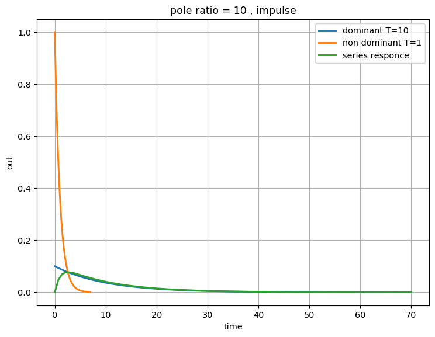

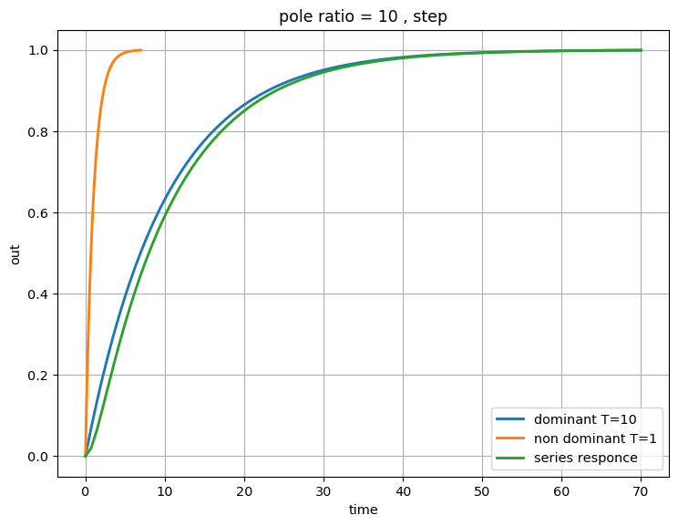

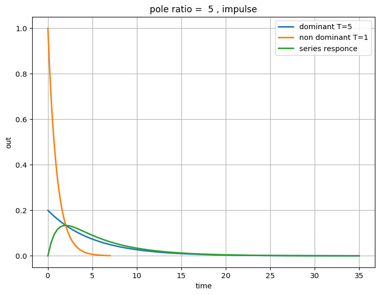

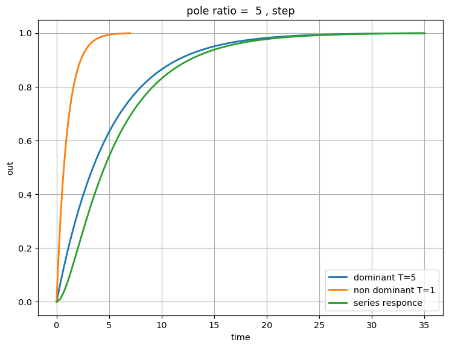

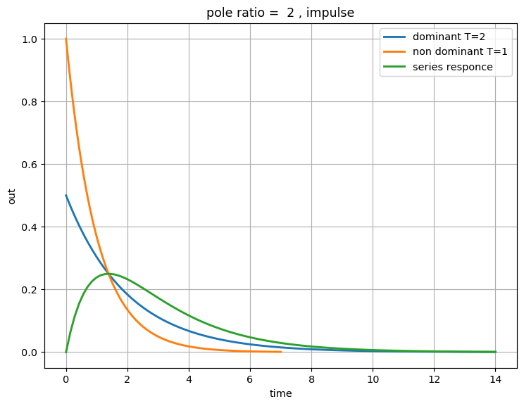

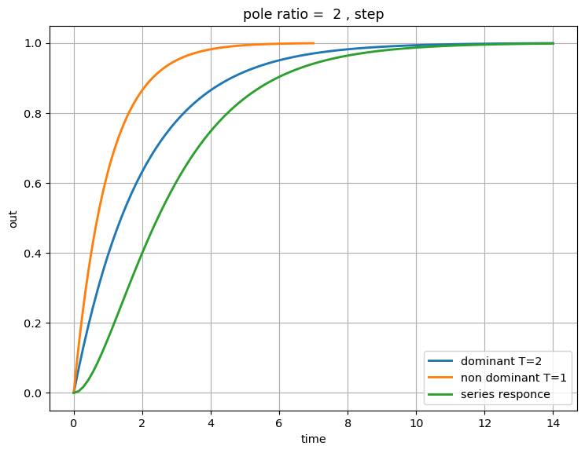

```python
def get_dom_responces(pole_dom,pole_non,resfunc):
    sys_dominant = sys_1st(1,pole_dom)
    sys_nondom = sys_1st(1,pole_non)
    sys_series = series(sys_dominant,sys_nondom)
    systems = [sys_dominant,sys_nondom,sys_series]
    out = [resfunc(sys) for sys in systems]
    data = [(tup[1],tup[0],"",label) for tup,label
            in zip(out,["dominant T="+str(pole_dom),"non dominant T="+str(pole_non),"series responce"])]
    return data
data_all =[
    ("pole ratio = 10 , impulse",get_dom_responces(10,1,impulse)),
    ("pole ratio = 10 , step",get_dom_responces(10,1,step)),
    ("pole ratio =  5 , impulse",get_dom_responces(5,1,impulse)),
    ("pole ratio =  5 , step",get_dom_responces(5,1,step)),
    ("pole ratio =  2 , impulse",get_dom_responces(2,1,impulse)),
    ("pole ratio =  2 , step",get_dom_responces(2,1,step)),
]

for data in data_all:
    draw_alldata(data[1])
    title(data[0])
    xlabel("time")
    ylabel("out")
```

## ボード線図

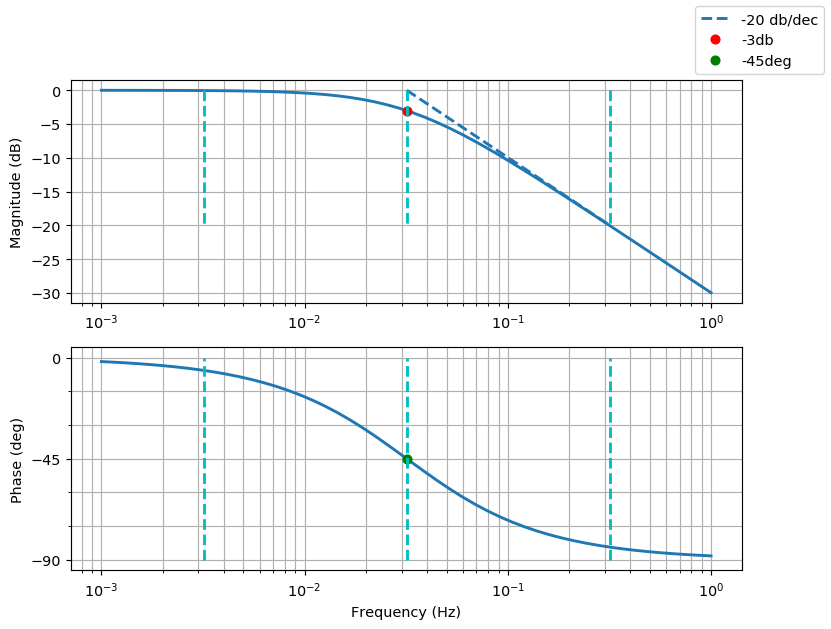

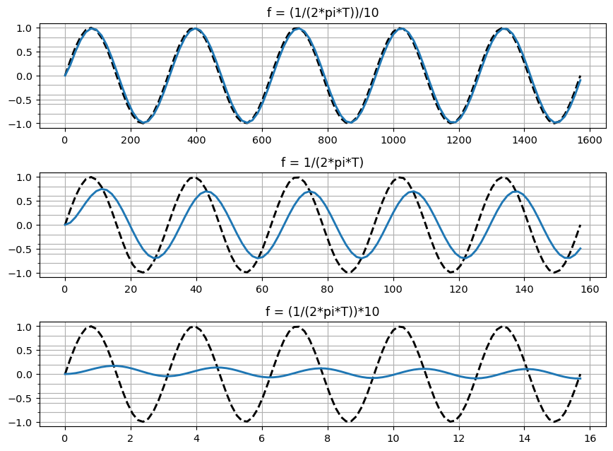

```python
def draw_bode(sys):
    bode(sys)
    ax1 = gcf().axes[0]
    lin1 = ax1.lines[-1]
    ax2 = gcf().axes[1]
    lin2 = ax2.lines[-1]
    return ax1,ax2,lin1,lin2

T = 5
syst = sys_1st(1,T)
fn = 1/(2*pi*T)

figure()
ax1,ax2,lin1,_ = draw_bode(syst,)
"1/(Ts+1)"
ax1.plot([fn,fn*10],[0,-20],"--",color=lin1._color,label="-20 db/dec")
ax1.plot(fn,-3,'or',label="-3db")
ax2.plot(fn,-45,'og',label="-45deg")
gcf().legend()

# draw servo analyzer sim point
freq = [fn/10,fn,fn*10]
ttl = ["(1/(2*pi*T))/10","1/(2*pi*T)","(1/(2*pi*T))*10"]
for i in range(3):
    ax1.plot([freq[i],freq[i]],[0,-20],'--c')
    ax2.plot([freq[i],freq[i]],[-90,0],'--c')

# servo analyzer sim
N=5
resol = 20
pts = linspace(0,N,resol*N)
theta = pts*2*pi
u = sin(theta)
figure()
for i,f in enumerate(freq):
    t = theta / (2*pi*f)
    data = lsim(syst,U=u,T=t)
    subplot(3,1,i+1)
    plot(t,u,'k--',label="input")
    plot(data[1],data[0],label="responce")
    title("f = " +ttl[i])
    gspec = gcf().axes[i].get_yticks()
    tck = linspace(-1,1,11)
    gcf().axes[i].set_yticks(tck,minor=True)
    grid(which="both")
tight_layout()
```

## 拡張1次遅れ

1次遅れと同様に，時定数TとスケールKで決まるシステムは実は4パターンある

- 右肩下がり : $\frac{1}{Ts+1}$
- 右肩上がり : $Ts+1$
- 左肩下がり : $\frac{Ts}{Ts+1}$
- 左肩上がり : $\frac{Ts+1}{Ts}$

どれも折点周波数は同じ. PIDを考えるときにちょくちょく出てくるから知っとくと役に立つ．

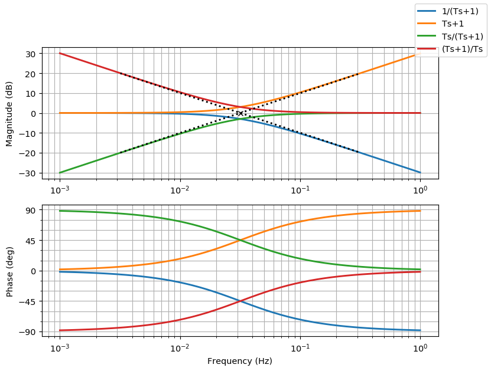

```python
figure()
syss = [
    (tf([1],[T,1]) , "1/(Ts+1)"),
    (tf([T,1],[1]) , "Ts+1"),
    (tf([T,0],[T,1]), "Ts/(Ts+1)"),
    (tf([T,1],[T,0]), "(Ts+1)/Ts"),
]
    # ,tf([-T,0],[T,1])
for sys in syss:
    ax1,ax2,lin1,lin2 = draw_bode(sys[0])
    lin1.set_label(sys[1])
gcf().axes[0].plot(fn,0,"kx")
gcf().axes[0].plot([0.1*fn,10*fn],[20,-20],"k:")
gcf().axes[0].plot([0.1*fn,10*fn],[-20,20],"k:")
gcf().legend()
```

# 二次遅れ

一般系 $$G(s) = \frac{\omega_n^2}{s^2 + 2\zeta\omega_ns + \omega_n^2}$$ $$\frac{d^2x}{dt^2}+2\zeta \omega_n\frac{dx}{dt}+\omega_n^2x = \frac{1}{k}\omega_n^2f$$

極 $$s=-\zeta\omega_n \pm \omega_n\sqrt{\zeta^2-1}$$

周波数特性 $$|G(j\omega)| = \frac{\omega_n^2}{\sqrt{(\omega^2 - \omega_n^2)^2+(2\zeta \omega_n\omega)^2}}$$ $$ \begin{eqnarray} \angle G(j\omega) = \begin{cases} -tan^{-1}\frac{2\zeta\omega_n}{\omega_n^2 - \omega^2} \\ -90 \\ -180-tan^{-1}\frac{2\zeta\omega_n}{\omega_n^2 - \omega^2} \end{cases} \end{eqnarray} $$

ゲイン=-3dbとなる周波数(バンド幅)は $$\omega_b = \omega_n\sqrt{(1-2\zeta^2)^2+\sqrt{(1-2\zeta^2)^2+1}}$$

## 代表例

機械系 $$ \begin{eqnarray} m\frac{d^2x}{dt^2}+d\frac{dx}{dt}+kx &=& f \\ \iff \frac{d^2y}{dt^2}+2\zeta \omega_n\frac{dy}{dt}+\omega_n^2y &=& \frac{1}{k}\omega_n^2x \end{eqnarray} $$ ただし$\zeta=\frac{d}{2\sqrt{km}}$,$\omega_n=\sqrt{\frac{k}{m}}$

## 時間応答と極配置

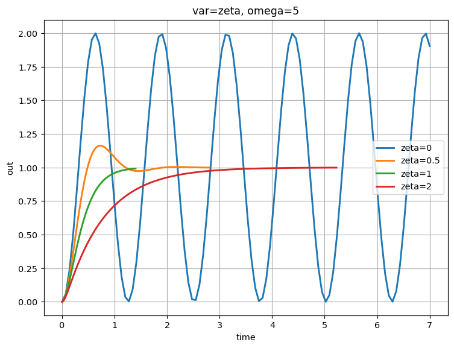

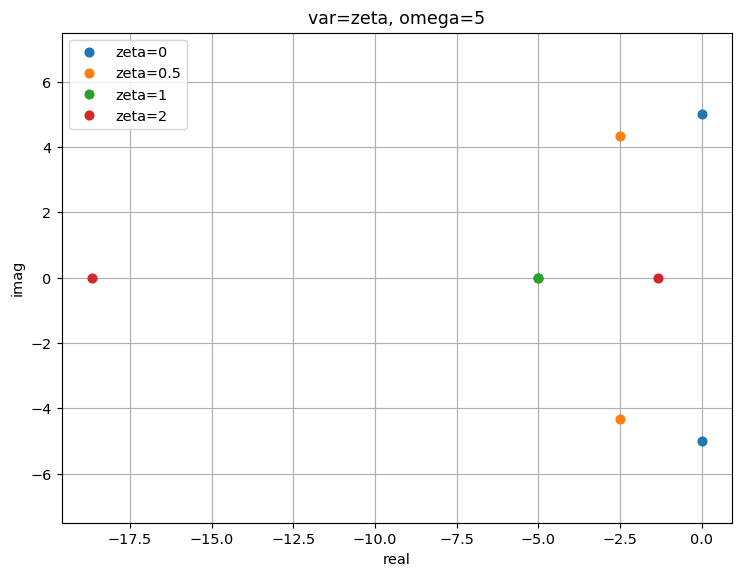

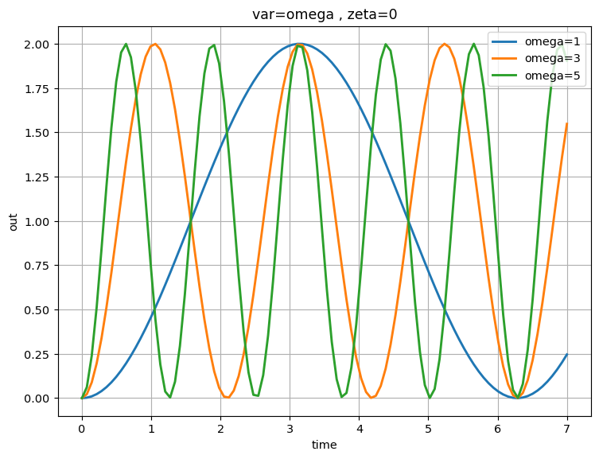

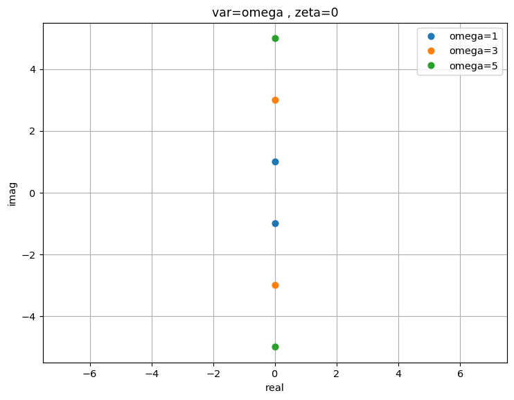

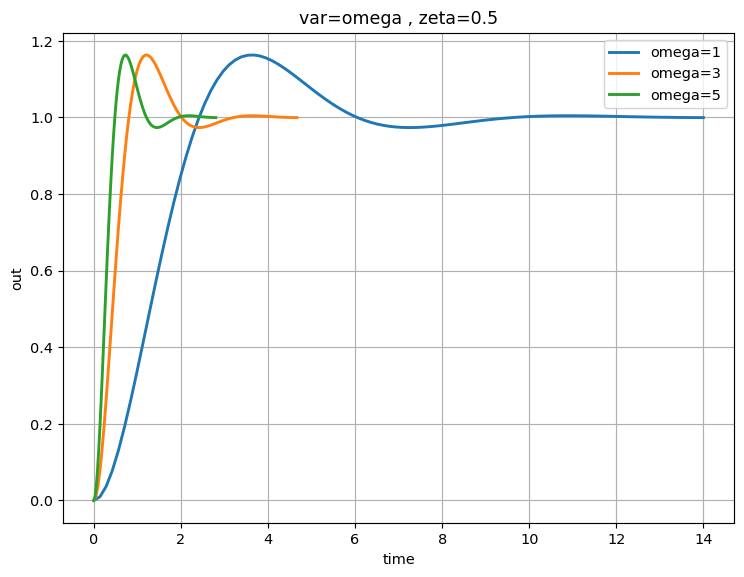

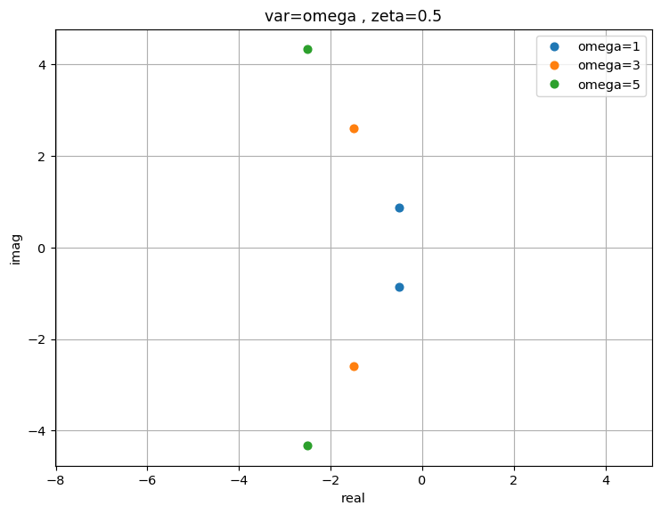

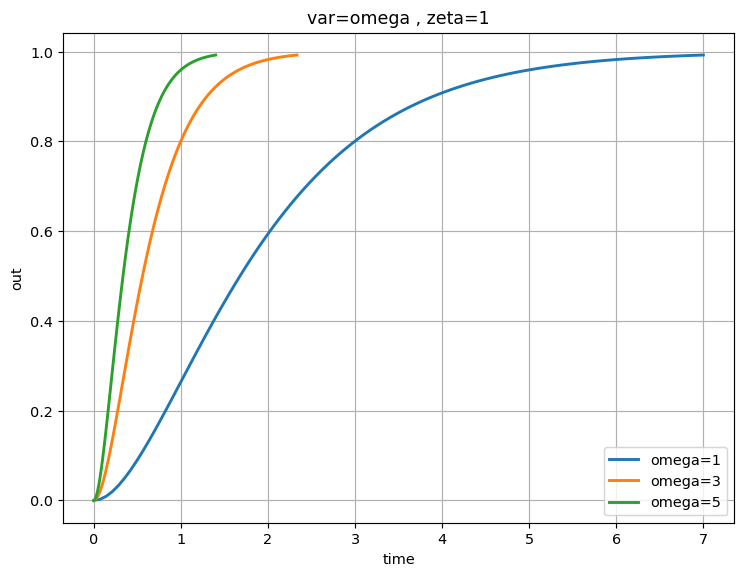

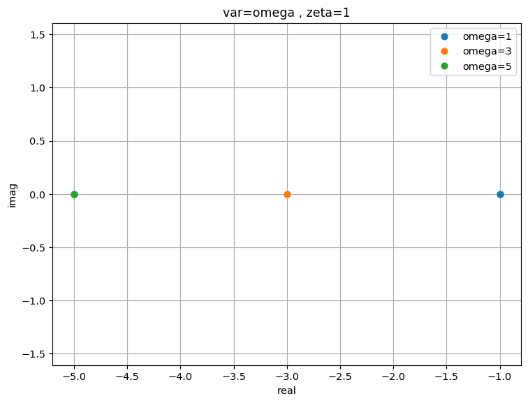

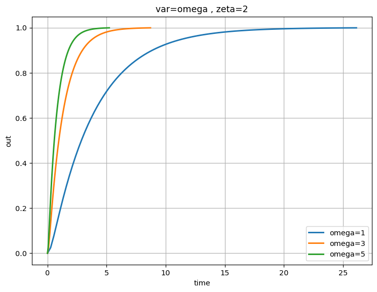

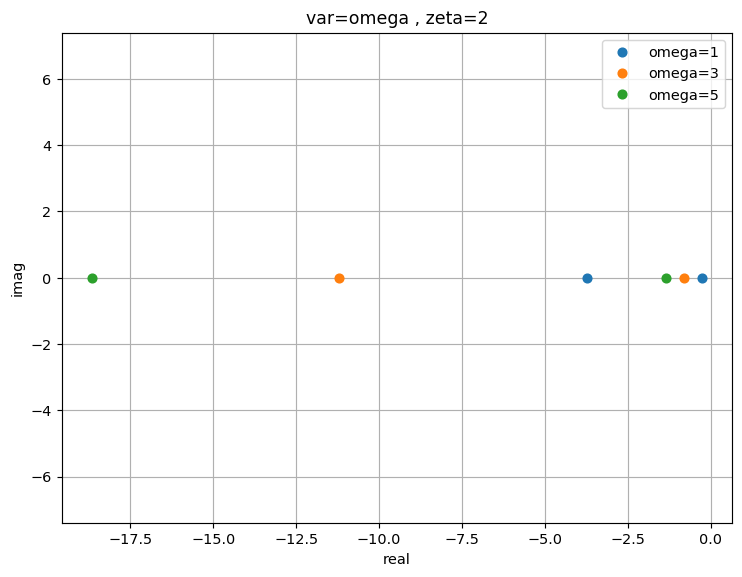

```python
zeta = [0,0.5,1,2]
omega = [1,3,5]
def get_poles(sysparam,sysfunc,label_prefix=""):
    systems = [sysfunc(s) for s in sysparam]
    polelist = [pole(sys) for sys in systems]
    data = [(p.real,p.imag,s,label_prefix) for s,p in zip(sysparam,polelist)]
    return data

# basic step responce
data_all_step = [
    ("var=zeta, omega=5",get_responces(zeta,lambda x : sys_2nd(1,5,x),step,"zeta=")),
]
# pole placement
data_all_pole = [
    ("var=zeta, omega=5",get_poles(zeta,lambda x : sys_2nd(1,5,x),"zeta=")),
]
for z in zeta:
    data_all_step.append((
        "var=omega , zeta="+str(z),
        get_responces(omega,lambda x : sys_2nd(1,x,z),step,"omega=")))
    data_all_pole.append((
        "var=omega , zeta="+str(z),
        get_poles(omega,lambda x : sys_2nd(1,x,z),"omega=")))

for datas,datap in zip(data_all_step,data_all_pole):
    draw_alldata(datas[1])
    title(datas[0])
    xlabel("time")
    ylabel("out")

    draw_alldata(datap[1],'o')
    title(datap[0])
    xlabel("real")
    ylabel("imag")
    axis("equal")
```

## ボード線図

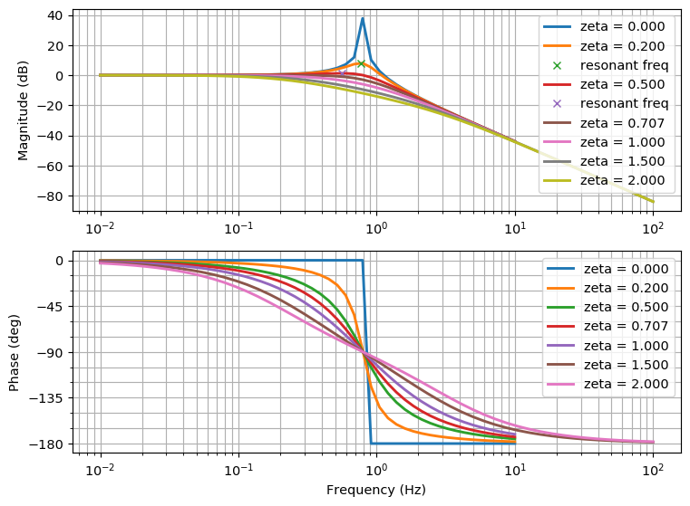

```python
wn = 5
zeta = [0,0.2,0.5,1/sqrt(2),1,1.5,2]
syst = [sys_2nd(1,wn,z) for z in zeta]

f=figure()
for sy,z in zip(syst,zeta):
    bode(sy)
    ax1 = f.axes[0]
    ax2 = f.axes[1]
    lin1 = ax1.lines[-1]
    lin2 = ax2.lines[-1]
    lin1.set_label("zeta = {0:.3f}".format(z))
    lin2.set_label("zeta = {0:.3f}".format(z))
    if 0< z and z<1/sqrt(2):
        wp = wn*sqrt(1-2*z*z)
        gp = 1/(2*z*sqrt(1-z*z))
        ax1.plot(wp/(2*pi),20*log10(gp),'x',label='resonant freq')
ax1 = f.axes[0]
ax1.legend()
ax2 = f.axes[1]
ax2.legend()
```

# PID制御

```
  ┌─P─┐
──┼─I─┼─>
  └─D─┘
```

P,I,Dそれぞれのコントローラを並列に接続したとき，コントローラの伝達関数は以下． $$C(s)=K_p+\frac{K_i}{s}+K_ds=K_p \left(1 + \frac{1}{T_is}+ T_ds \right)$$ ただし，以下の変数変換を行った． $$T_i = \frac{K_p}{K_i} \\ T_d = \frac{K_d}{K_p}$$

なお，$T_i,T_d$はそれぞれ積分時間，微分時間と呼ばれる． 厳密には時間ではなくて，Kpの次元(または逆数の次元)に対して，時間次元を乗じたものになる． ここで，$T_i >> T_d$を仮定するとコントローラの伝達関数は以下のようになる． $$C(s) = K_p\frac{T_is+1}{T_is}(T_ds+1) = C_p(s)C_i(s)C_d(s)$$ ただし，以下の変数変換を行った． $$ \begin{eqnarray} C_p(s) &=& K_p \\ C_i(s) &=& \frac{T_is+1}{T_is} \\ C_d(s) &=& T_ds+1 \end{eqnarray} $$

つまり，PIDコントローラは$C_p,C_i,C_d$の直列接続で表すことができる．以降それぞれを比例コントローラ，微分コントローラ，積分コントローラと呼ぶ． また，$C_i,C_d$は"拡張1次遅れボード線図"で見たように，それぞれ1次遅れ系の仲間であり，$T_i,T_d$が時定数になっている．(そういう意味で微分時間，積分時間と言っているのかも)

```
─Cp─Ci─Cd─>
```

ところで，上記のカスケードPIDコントローラは$T_i >> T_d$を仮定していた．これをボード線図上で考えると，折点周波数=1/2\pi T$だから，「積分コントローラ(左肩上がりの一次遅れ)の折点周波数」 << 「微分コントローラ(右肩上がりの一次遅れ)の折点周波数」になる． つまり，ボード線図上でPIDコントローラ全体のゲインは＼＿／のような凹型になるべきである． (参考書によれば折点周波数の大小関係を逆転するような熟練技もあるらしい)

## PD制御

$$C_{pi}(s) = Kp(1+Tds)$$

右肩上がりの一次遅れ系と同じ形

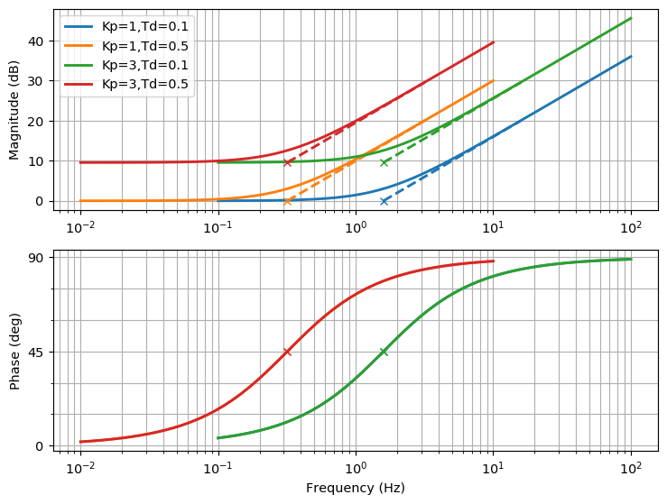

```python
Kp_list=[1,3]
Td_list=[0.1,0.5]
Ti_list=[10,50]

ctl = [(tf([Kp*Td,Kp],[1]),Kp,Td) for Kp,Td in it.product(Kp_list,Td_list)]
figure()
for sys,Kp,Td in ctl:
    ax1,ax2,line,_ = draw_bode(sys)
    line.set_label("Kp={0},Td={1}".format(Kp,Td))
    fcf = 1/(2*pi*Td)
    ax1.plot(fcf,mag2db(Kp),'x',color=line._color)
    ax1.plot([fcf,fcf*10],[mag2db(Kp),mag2db(Kp*10)],'--',color=line._color)
    ax2.plot(fcf,45,'x',color=line._color)
gcf().axes[0].legend()
```

## 不完全微分を用いたPD制御

微分コントローラ$C_d(s)$は入力周波数→∞に対して出力→∞になるため，例えばステップ入力などに対して極大な出力をしてしまう． 実装上は出力に対して最大値制限をかけることで回避できるが，それだとボード線図上で扱いにくい． そこで，$C_d(s)$に追加の微分抑制コントローラ$C_{d0}$をカスケード結合することを考える．

```
─Cd─Cd0─>
```

微分抑制コントローラ$C_{d0}$の要件は以下．

- 低域ゲイン = $0 db$
- 高域ゲイン = $-20db / dec$
  - → 右肩下がりの一次遅れ系の形をしていればよい．
- 微分コントローラよりも高域に接点周波数を持つ
- 微分コントローラのゲインが最大制限値に等しくなるような接点周波数を持つ

具体的に微分抑制コントローラの形を考える．

- 微分抑制コントローラの接点周波数$f_0$を微分コントローラの接点周波数$f_d$の$N$倍とする
  - $f_0 = Nf_d = \frac{N}{2\pi T_d}$
- このとき，$N$は出力の最大制限値[db]から決める．
  - $f_0$における微分コントローラゲイン = $20log_{10}(N)$
  - なぜならボード線図上で20db/decだから
  - さらに，$f_0$におけるPIコントローラ全体のゲイン = $20log_{10}(K_pN)$
  - ↑が出力最大制限値とイコールになるように$N$を決める
- 微分抑制コントローラの時定数$T_n$を接点周波数の式から求める
  - $T_0 = \frac{T_d}{N}$
- よって，微分抑制コントローラの伝達関数$C_{d0}$は以下 $$C_{d0}(s) = \frac{1}{Td/N +1}$$

この形は$\alpha < 1 , \beta > 1$であるから，位相進み補償器に等しい. ボード線図を見ると，確かに全領域で位相>0になっている． 位相進め要素である微分コントローラに細工をしたら位相進み補償器になる，と考えるとなんとなく位相進み補償器の得体が知れてくるように思う．

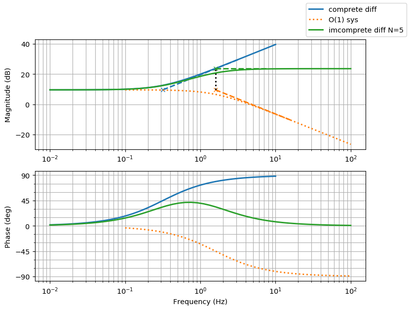

```python
Kp = Kp_list[-1]
Td = Td_list[-1]
N=5
fcf = N/(2*pi*Td)
fc = 1/(2*pi*Td)
fmax = sqrt(fc*fcf)

imcompctl = tf([Kp*Td,Kp],[Td/N,1])
ctl = tf([Kp*Td,Kp],[1])
sub = tf([Kp],[Td/N,1])

figure()
ax1,_,line,_ = draw_bode(ctl)
line.set_label("comprete diff")
ax1.plot(fc,mag2db(Kp),"x",color=line._color)
ax1.plot([fc,fc*10],[mag2db(Kp),mag2db(Kp*10)],"--",color=line._color)

ax1,_,line,line2 = draw_bode(sub)
line.set_label("O(1) sys")
line.set_linestyle(":")
line2.set_linestyle(":")
ax1.plot([fcf,fcf*10],[mag2db(Kp),mag2db(Kp/10)],"--",color=line._color)
ax1.plot(fcf,mag2db(Kp),"x",color=line._color)
ax1.plot([fcf,fcf],[mag2db(Kp),mag2db(Kp*N)],"k:")

ax1,ax2,line,_ = draw_bode(imcompctl)
line.set_label("imcomprete diff N={0}".format(N))
ax1.plot(fcf,mag2db(N*Kp),'x',color=line._color)
ax1.plot([fcf,fcf*N],[mag2db(N*Kp),mag2db(N*Kp)],"--",color=line._color)

gcf().legend()
```

## 位相進み補償器としての不完全微分

伝達関数は以下で与えられる $$C_{plead}(s) = K \frac{ T s +1}{ \alpha Ts+1} \ \ \ \mathrm{where} \ \alpha<1$$ この形は，上記の不完全微分を用いたPDコントローラと等価であることはここまでの議論でわかっている．

2つの折点周波数は低い方から以下で与えられる $$f_L = \frac{1}{2\pi T} \\ f_H \frac{1}{2\pi \alpha T}$$

位相を最大にすすめる周波数,角速度は以下で与えられる $$f_{max}=\sqrt{f_L f_H} = \frac{1}{2 \pi T \sqrt{\alpha}} \\ \omega_{max}=2\pi f_{max}$$

最大位相進みにおけるゲイン$G_{max}$と位相$\phi_{max}$は以下で与えられる $$ G_{max} = |C_{plead}(j\omega)|_{\omega=\omega_{max}} = \frac{K}{\sqrt{alpha}} \\ \phi_{max} = \angle C_{plead}(j\omega)_{\omega=\omega_{max}} = tan^{-1}\frac{1-\alpha}{2\sqrt{\alpha}} $$

したがって，最大位相進みから位相進み補償器を設計する場合，係数$\alpha$は以下で与えられる． $$\alpha = \frac{1-sin\phi_{max}}{1+sin\phi_{max}}$$

位相進み補償器は，特にゲインがゼロクロスする周波数領域にて位相を進める事によって位相余裕確保に利用する．

## PI制御

$$C_pi(s) = Kp\frac{T_is+1}{T_is}$$

左肩上がりの一次遅れ系と同じ形

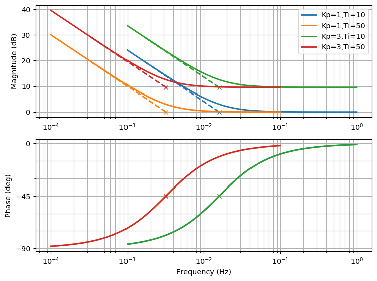

```python
# pi
ctl = [(tf([Kp*Ti,Kp],[Ti,0]),Kp,Ti) for Kp,Ti in it.product(Kp_list,Ti_list)]
figure()
for sys,Kp,Ti in ctl:
    ax1,ax2,line,_ = draw_bode(sys)
    line.set_label("Kp={0},Ti={1}".format(Kp,Ti))
    fcf = 1/(2*pi*Ti)
    ax1.plot(fcf,mag2db(Kp),'x',color=line._color)
    ax1.plot([fcf,fcf/10],[mag2db(Kp),mag2db(Kp*10)],'--',color=line._color)
    ax2.plot(fcf,-45,'x',color=line._color)
gcf().axes[0].legend()
```

## 不完全積分を用いたPI制御

入力周波数→0(直流)のとき，積分コントローラ出力→∞になってしまう

不完全微分と同様に抑制コントローラ$C_{i0}$をカスケード結合する．

積分抑制コントローラの要件は以下．

- 低域ゲイン = $20 db/dec$
- 高域ゲイン = $0 db$
  - → 左肩下がりの一次遅れ系の形をしていればよい．
- 積分コントローラよりも低域に接点周波数を持つ
- 積分コントローラのゲインが最大制限値に等しくなるような接点周波数を持つ

具体的に積分抑制コントローラの形を考える．

- 積分抑制コントローラの接点周波数$f_0$を積分コントローラの接点周波数$f_i$の$1/N$倍とする
  - $f_0 = f_i/N = \frac{1}{2\pi T_d N}$
- このとき，$N$は出力の最大制限値[db]から決める．
  - $f_0$における積分コントローラゲイン = $-20log_{10}(1/N)$
  - なぜならボード線図上で-20db/decだから
  - さらに，$f_0$におけるPIコントローラ全体のゲイン = $20log_{10}(K_pN)$
  - ↑が出力最大制限値とイコールになるように$N$を決める
- 積分抑制コントローラの時定数$T_0$を接点周波数の式から求める
  - $T_0 = T_iN$
- よって，積分抑制コントローラの伝達関数$C_{i0}$は以下 $$C_{i0}(s) = N\frac{T_is+1}{NT_is+1}$$

なので，不完全積分を用いたPIコントローラの伝達関数は $$C'_{pi}(s) = K_p N\frac{T_is+1}{NT_is+1}$$

この形はN>1より，後述の位相遅れ補償器に等しい

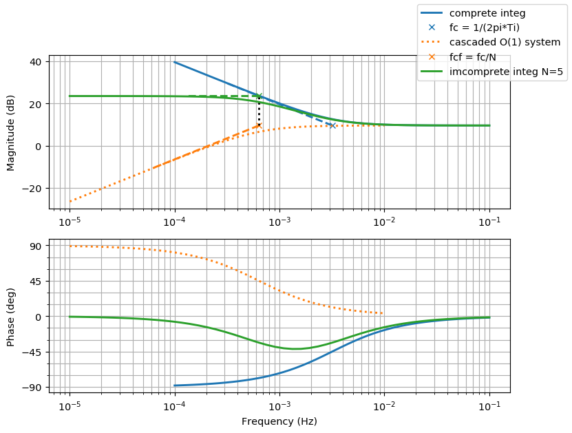

```python
Kp = Kp_list[-1]
Ti = Ti_list[-1]
N=5
fcf = 1/(2*pi*Ti*N)
fc = 1/(2*pi*Ti)

imcompctl = tf([Kp*N*Ti,Kp*N],[N*Ti,1])
ctl = tf([Kp*Ti,Kp],[Ti,0])
sub = tf([Kp*N*Ti,0],[N*Ti,1])

figure()
ax1,_,line,_ = draw_bode(ctl)
line.set_label("comprete integ")
ax1.plot(fc,mag2db(Kp),"x",color=line._color,label="fc = 1/(2pi*Ti)")
ax1.plot([fc,fc/10],[mag2db(Kp),mag2db(Kp*10)],"--",color=line._color)

ax1,_,line,line2 = draw_bode(sub)
line.set_label("cascaded O(1) system")
line.set_linestyle(":")
line2.set_linestyle(":")
ax1.plot(fcf,mag2db(Kp),"x",color=line._color,label="fcf = fc/N")
ax1.plot([fcf,fcf/10],[mag2db(Kp),mag2db(Kp/10)],"--",color=line._color)
ax1.plot([fcf,fcf],[mag2db(Kp),mag2db(Kp*N)],"k:")

ax1,_,line,_ = draw_bode(imcompctl)
line.set_label("imcomprete integ N={0}".format(N))
ax1.plot(fcf,mag2db(N*Kp),'x',color=line._color)
ax1.plot([fcf,fcf/N],[mag2db(N*Kp),mag2db(N*Kp)],"--",color=line._color)
gcf().legend()
```

## 位相遅れ補償器としての不完全積分

伝達関数は以下で与えられる $$C_{plag}(s) = K \beta \frac{Ts+1}{\beta Ts+1} \ \ \ \mathrm{where} \ \beta>1$$ この形は，上記の不完全積分を用いたPIコントローラと等価であることはここまでの議論でわかっている．

2つの折点周波数は低い方から以下で与えられる $$f_L = \frac{1}{2\pi \beta T} \\ f_H \frac{1}{2\pi T}$$

位相を最大に遅らせる周波数,角速度は以下で与えられる $$f_{min}=\sqrt{f_L f_H} = \frac{1}{2 \pi T \sqrt{\beta}} \\ \omega_{min}=2\pi f_{min}$$

最大位相遅れにおけるゲイン$G_{min}$と位相$\phi_{min}$は以下で与えられる $$ G_{min} = |C_{plag}(j\omega)|_{\omega=\omega_{max}} = \frac{K}{\sqrt{\beta}} \\ \phi_{min} = \angle C_{plag}(j\omega)_{\omega=\omega_{max}} = tan^{-1}\frac{\beta-1}{2\sqrt{\beta}} $$

位相遅れ補償器は低周波領域でのゲイン改善に用いる(位相を遅らせる代わりにゲインを上げる使い方)． 基本的に位相を遅らせることは特性改善に繋がらないので，位相を補償する用途では使わない． 低周波ゲインを改善する = 直流成分の入力に対して出力が大きくなる = 直流成分の偏差に対して出力が大きくなる = 定常偏差に対して出力が大きくなる = 定常偏差が小さくなる，と考えればOK

## PID制御

$$C(s) = K_p\frac{T_is+1}{T_is}(T_ds+1)$$

今まで出てきた要素の重ね合わせ

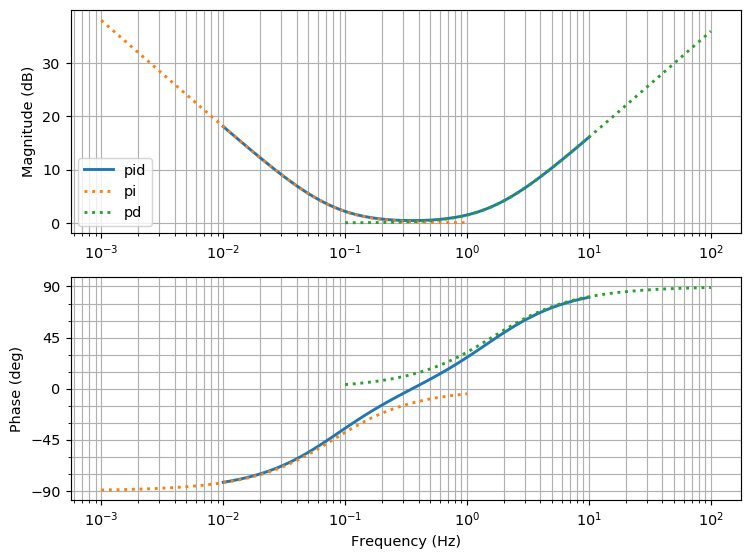

```python
# pid
Kp=Kp_list[0]
Td=Td_list[0]
Ti=Td*20
cp = tf([Kp],[1])
ci = tf([Ti,1],[Ti,0])
cd = tf([Td,1],[1])
figure()
_,_,l1,_ = draw_bode(series(cp,ci,cd))
l1.set_label("pid")
_,_,l1,l2 = draw_bode(series(cp,ci))
l1.set_linestyle(":")
l2.set_linestyle(":")
l1.set_label("pi")
_,_,l1,l2 = draw_bode(series(cp,cd))
l1.set_linestyle(":")
l2.set_linestyle(":")
l1.set_label("pd")
gcf().axes[0].legend()
```

## ノッチフィルタ

基本的にPID制御で振動しないように制御するためには応答性=低域ゲインを犠牲にする必要がある． (共振点でのゲインを下げる=比例ゲインを下げる=全体のゲインが下がる)

ノッチフィルタを使えば，PID特性をそのままに，特定周波数のゲインだけを下げることができる． $$C(s) = \frac{s^2+2R\zeta_N\omega_Ns+\omega_N^2}{s^2+2\zeta_N\omega_Ns+\omega_N^2}$$

- $\omega_N$ : ゲインを下げたい周波数
- $R$ : ノッチの深さ．$\omega=\omega_N$におけるゲインが$20log_{10}(R)$になる
- $\zeta_N$ : ノッチの幅． $\frac{1}{10}\zeta_N\omega_N < \omega_N < 10\zeta_N\omega_N$の範囲内のゲインが0db以下になる

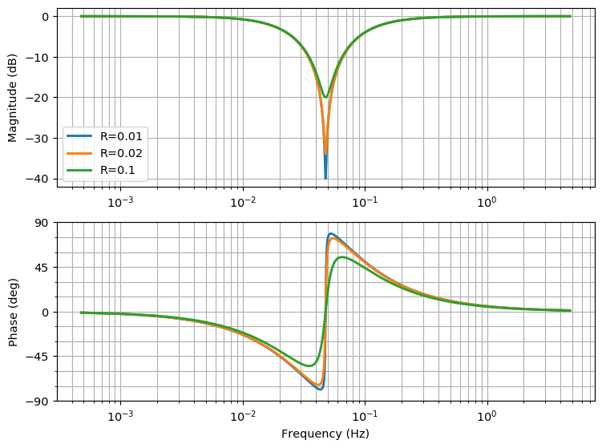

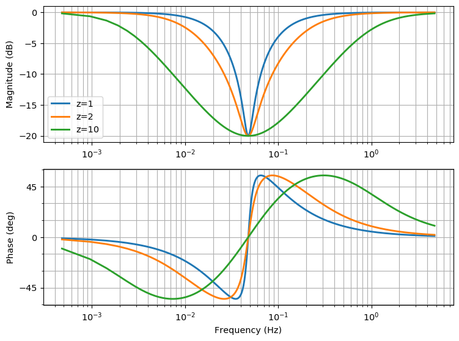

```python
def draw_bode2(sys,omega):
    bode(sys,omega)
    f= gcf()
    ax1=f.axes[0]
    ax2=f.axes[1]
    line1 = ax1.lines[-1]
    line2 = ax2.lines[-1]
    return ax1,ax2,line1,line2

def Cn(R,z,w):
    return tf([1,2*R*z*w,w**2],[1,2*z*w,w**2])

w=0.3
osamp =linspace(w/100,w*100,10000)
figure()
_,_,l,_=draw_bode2(Cn(0.01,1,w),osamp)
l.set_label("R=0.01")
_,_,l,_=draw_bode2(Cn(0.02,1,w),osamp)
l.set_label("R=0.02")
_,_,l,_=draw_bode2(Cn(0.1,1,w),osamp)
l.set_label("R=0.1")
gcf().axes[0].legend()
figure()
_,_,l,_=draw_bode2(Cn(0.1,1,w),osamp)
l.set_label("z=1")
_,_,l,_=draw_bode2(Cn(0.1,2,w),osamp)
l.set_label("z=2")
_,_,l,_=draw_bode2(Cn(0.1,10,w),osamp)
l.set_label("z=10")
gcf().axes[0].legend()
```